# ERGM workshop

Jono Tuke

March 20, 2023

# Tobacco control dataset

## Description

Organizational network data collected from the Indiana state tobacco control program in 2010. The network is made up of 25 organizational nodes.

## Details

The dataset was obtained as part of an evaluation of state tobacco control programs funded by the Centers of Disease Control and Prevention (CDC). A tie exists when two organizations talked to each other about the CDC evidence-based guideline Best Practices for Tobacco Control.

## Node characteristics:

- `vertex.names` - Organization name
- `agency_lvl` - Level of agency:
  - 1 - Local
  - 2 - State
  - 3 - National
- `tob_yrs` - Number of years doing tobacco control

## Libraries

```r
pacman::p_load(
  tidyverse, igraph, ggraph,
  ergm, intergraph, UserNetR,
  tidygraph
)
```

## Get the data

```r
data("TCnetworks")
tobacco <- TCnetworks$TCcnt
```

## Cleaning

1. Convert to tidygraph.
2. Get rid of na columns in nodes and edge data-frames.

## Cleaning

```r
tobacco <- as_tbl_graph(tobacco)
tobacco <-
  tobacco |>
  activate(nodes) |>
  select(-na) |>
  activate(edges) |>
  select(-na)
tobacco
```

```
# A tbl_graph: 25 nodes and 175 edges
#
# An undirected simple graph with 1 component
#
# Edge Data: 175 × 3 (active)
   from    to contact
  <int> <int>   <dbl>
1     1     2       5
2     1     3       4
3     1     4       4
4     1     5       3
5     1     6       4
6     1     7       3
# … with 169 more rows
#
# Node Data: 25 × 5
  agency_cat agency_lvl lead_agency tob_yrs name
       <dbl>      <dbl>       <dbl>   <dbl> <chr>
1          1          2           1      21 ITPC
2          2          2           0       9 Promotus
3          2          3           0       3 RTI
# … with 22 more rows
```

## Graph statistics.

Get the following:

- Number of nodes
- Number of edges
- Density
- Transitivity

## Graph statistics.

```r
vcount(tobacco)
```

```
[1] 25
```

```r
ecount(tobacco)
```

```
[1] 175
```

```r
edge_density(tobacco)
```

```
[1] 0.5833333
```

```r
transitivity(tobacco)
```

```
[1] 0.6827262
```

## Node attributes.

Make this figure.

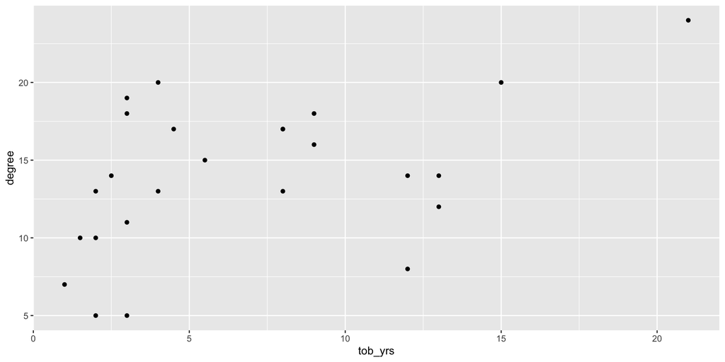

## Node attributes.

```r
tobacco |>
  activate(nodes) |>
  mutate(
    degree = centrality_degree()
  ) |>
  data.frame() |>
  ggplot(aes(tob_yrs, degree)) +
  geom_point()
```

## Visualise network.

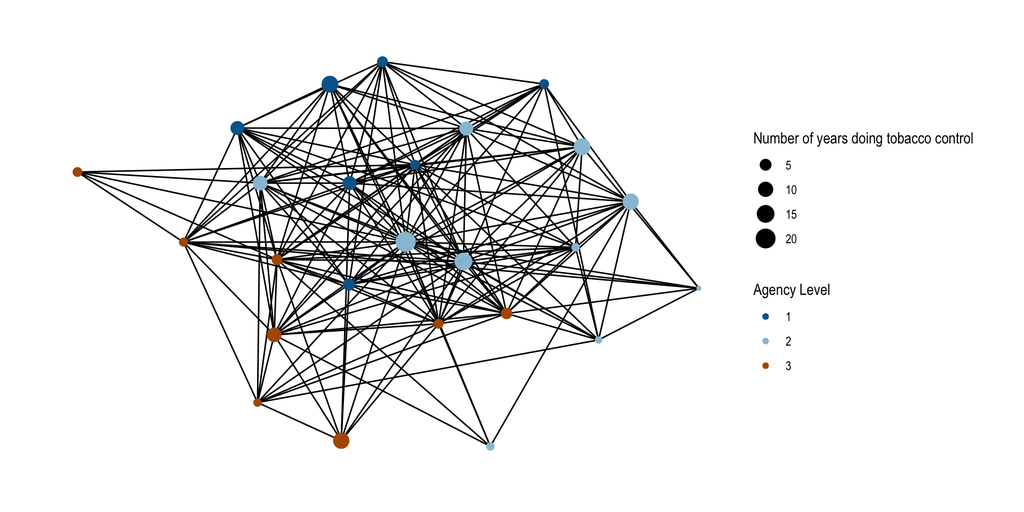